# Clustering: sports analytics

Hence, how many clusters?

In theory, we cannot answer this question. In practice, we can have some hints using screeplots:

Based on wss (total within sum of square)

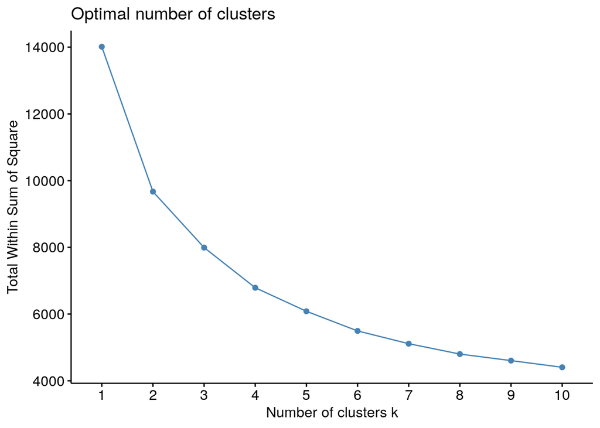

```r
fviz_nbclust(X, kmeans, method = 'wss')
```

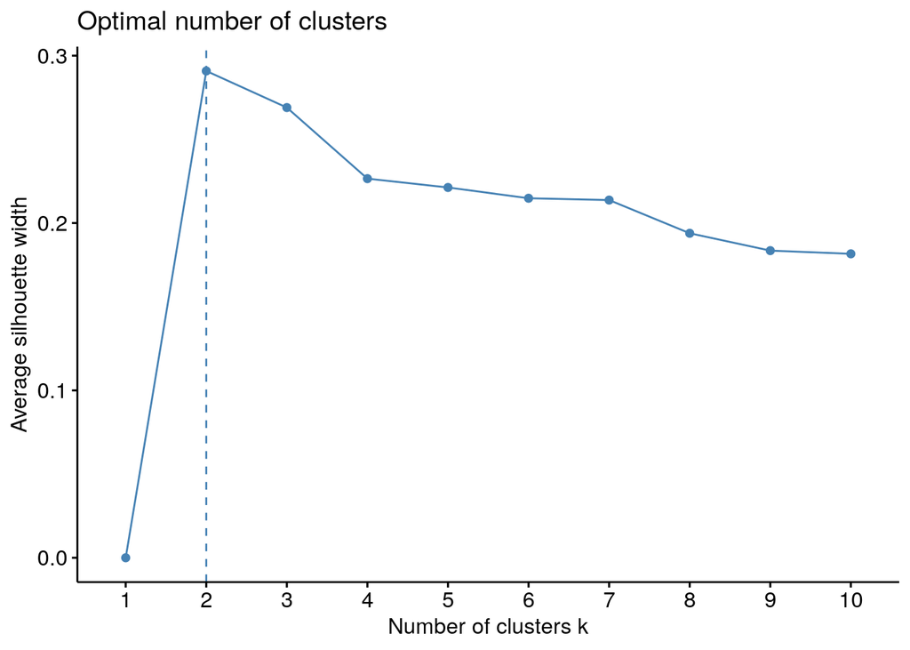

```r
fviz_nbclust(X, kmeans, method = 'silhouette')
```

Based on the gap statistic (using bootstrap)

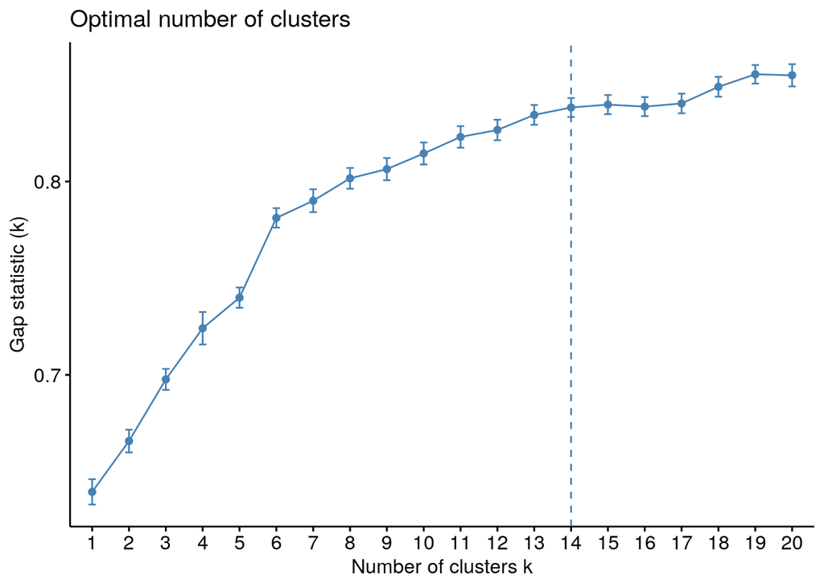

```r
fviz_nbclust(X, kmeans, method = 'gap_stat', k.max = 20)
```

Insights?

# Profile variables

We have some variables not included in the clustering. These are called **profiles** and may help us to understand better the clusters.

Let’s consider 3 clusters

```r
fit = kmeans(X, centers=3, nstart=100)
groups = fit$cluster
```

Let’s see the distribution of the clusters considering the minutes played

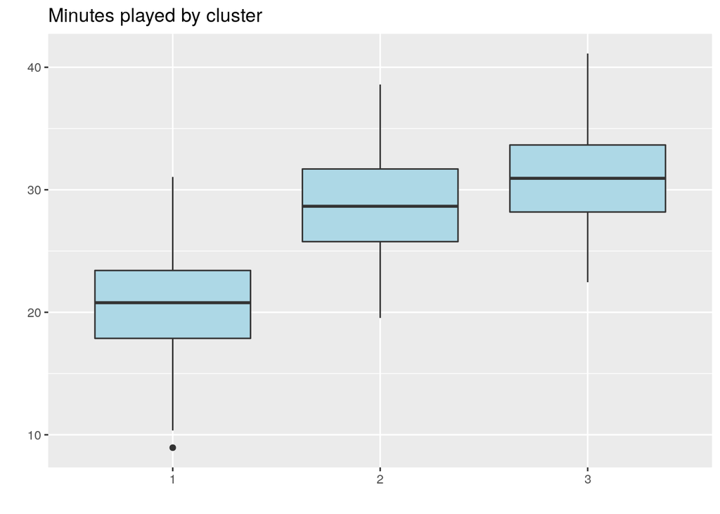

```r
as.data.frame(X) %>% mutate(cluster=factor(groups), names=names, min=min, gp=gp) %>%
  ggplot(aes(x = cluster, y = min)) +
  geom_boxplot(fill="lightblue") +
  labs(title = "Minutes played by cluster", x = "", y = "", col = "")
```

Seems players in one cluster play less minutes per game. It seems this cluster contains the worse players

Who are the other two clusters?

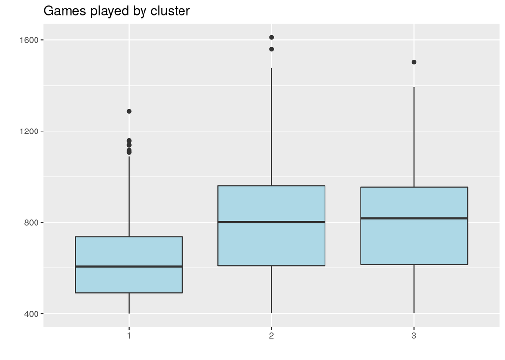

```r
as.data.frame(X) %>% mutate(cluster=factor(groups), names=names, min=min, gp=gp) %>%
  ggplot(aes(x = cluster, y = gp)) +
  geom_boxplot(fill="lightblue") +
  labs(title = "Games played by cluster", x = "", y = "", col = "")
```

Similar insights: one cluster has less experience

Clusplot

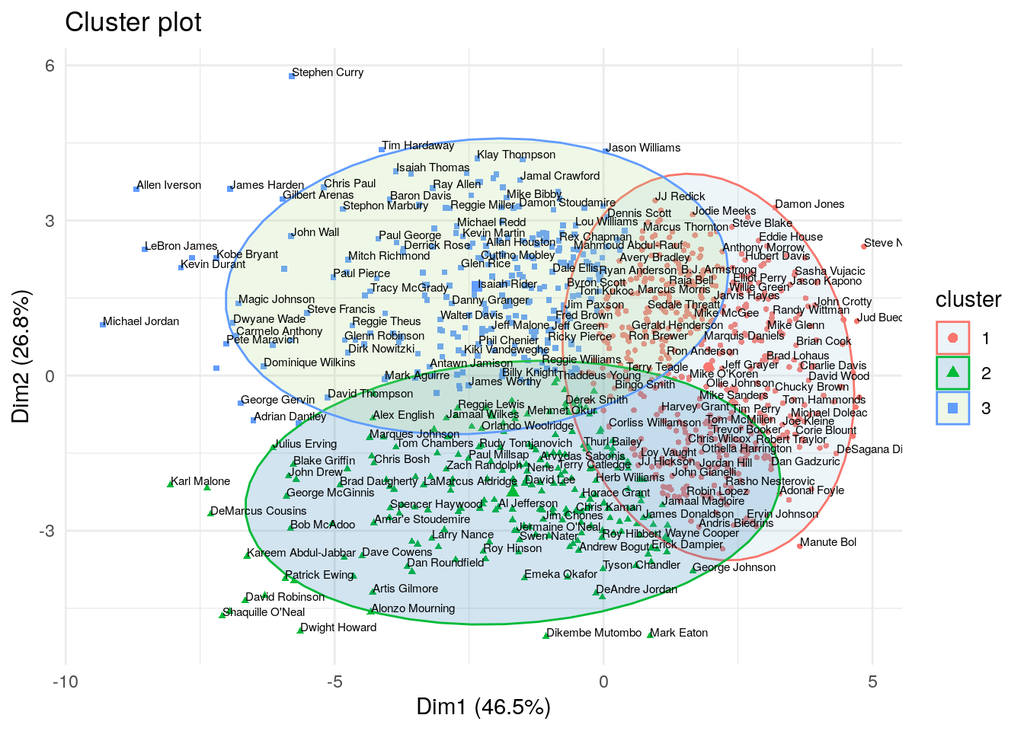

```r
fviz_cluster(fit, data = X, geom = c("point"),ellipse.type = 'norm', pointsize=1)+
  theme_minimal()+geom_text(label=names,hjust=0, vjust=0,size=2,check_overlap = T)+scale_fill_brewer(palette="Paired")
```

The clusplot is clearer: one cluster contains the worst players, and the best players are divided in two: interior and exterior players.

# kmeans with Mahalanobis distance

By default kmeans uses the Euclidean distance: circular distribution not considering correlations between variables

But how to incorporate these correlations, i.e. an elliptical distribution?

The Mahalanobis distance or the multivariate standardization:

```r
S_x <- cov(nba)
iS <- solve(S_x)
e <- eigen(iS)
V <- e$vectors
B <- V %*% diag(sqrt(e$values)) %*% t(V)
Xtil <- scale(nba,scale = FALSE)
nbaS <- Xtil %*% B
```

Take care: here we are assuming all the clusters have the same covariance matrix, that is, the same shape and orientations as the whole data

If this is not the case, we need mixture models (probabilistic clusters)

kmeans with 3 clusters assuming an elliptic distribution

```r
fit.mahalanobis = kmeans(nbaS, centers=3, nstart=100)
groups = fit.mahalanobis$cluster
centers=fit.mahalanobis$centers
colnames(centers)=colnames(X)
centers
```

```
##           fgm         fga        fg3m       fg3a         ftm         fta
## 1  0.03606123 -0.07585042 -0.21882247 -0.5457883  0.06222742  0.01503765
## 2 -0.09369265  0.20136749  0.40216863  1.1715172 -0.09004724 -0.10118730
## 3  0.06876693 -0.15472161 -0.02701127 -0.4624758 -0.04936790  0.17439448
##          oreb        dreb         ast          stl         blk          tov
## 1  0.07262309 -0.11726758  0.04058999  0.070661671 -0.39253726 -0.025350205
## 2 -0.27745936 -0.08786954  0.04525855  0.007220828 -0.09184746  0.004277494
## 3  0.34673880  0.69724312 -0.27616011 -0.312868039  1.85939595  0.096131476
##            pf          pts
## 1  0.06594278 -0.089576662
## 2 -0.14304358  0.159110922
## 3  0.05939451  0.001891677
```

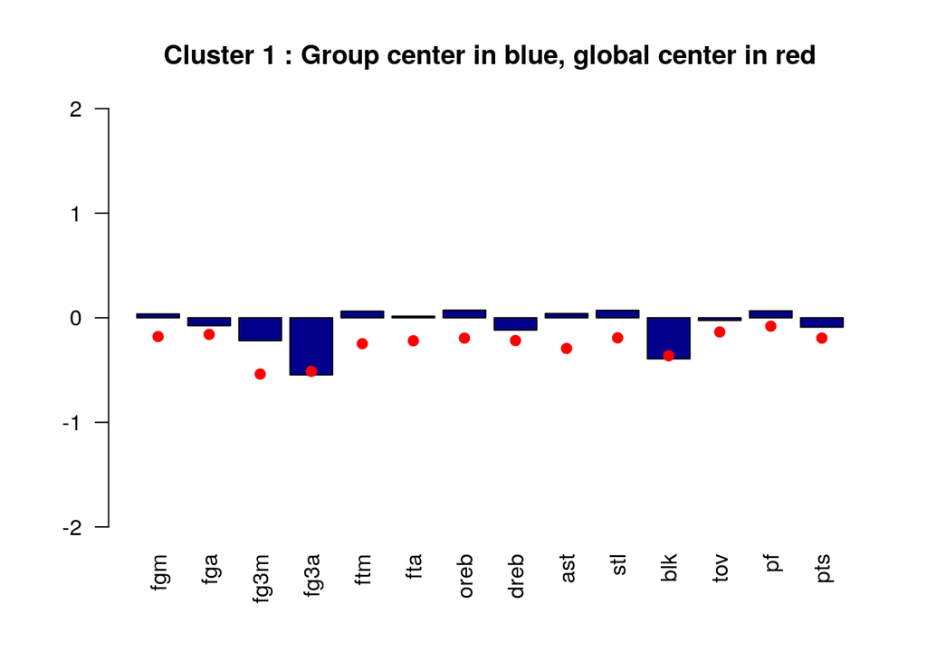

```r
i=1  # plotting the centers in cluster 1
bar1=barplot(centers[i,], las=2, col="darkblue", ylim=c(-2,2), main=paste("Cluster", i,": Group center in blue, global center in red"))
points(bar1,y=apply(X, 2, quantile, 0.50),col="red",pch=19)
```

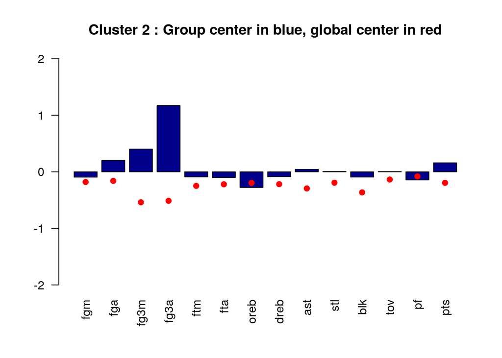

```r
i=2  # plotting the centers in cluster 2
bar2=barplot(centers[i,], las=2, col="darkblue", ylim=c(-2,2), main=paste("Cluster", i,": Group center in blue, global center in red"))
points(bar2,y=apply(X, 2, quantile, 0.50),col="red",pch=19)
```

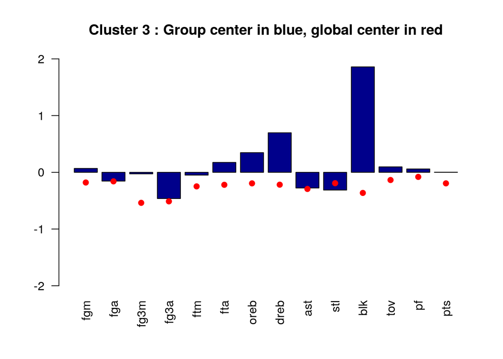

```r
i=3  # plotting the centers in cluster 3
bar3=barplot(centers[i,], las=2, col="darkblue", ylim=c(-2,2), main=paste("Cluster", i,": Group center in blue, global center in red"))
points(bar3,y=apply(X, 2, quantile, 0.50),col="red",pch=19)
```

clusplot

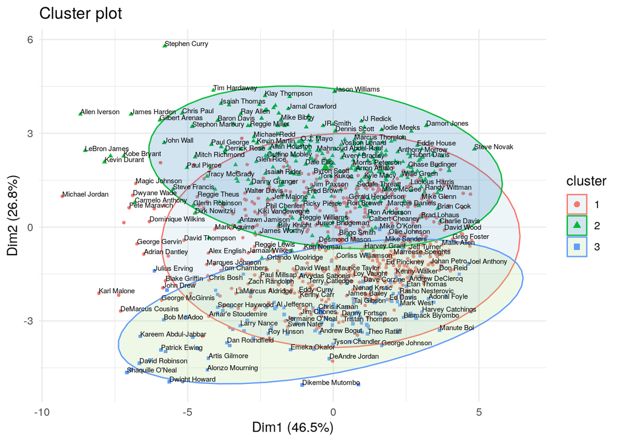

```r
fviz_cluster(fit.mahalanobis, data = X, geom = c("point"),ellipse.type = 'norm', pointsize=1)+
  theme_minimal()+geom_text(label=names,hjust=0, vjust=0,size=2,check_overlap = T)+scale_fill_brewer(palette="Paired")
```

Different insights now…

# How similar are the clusters?

The Adjusted Rand index compares two classifications: the closer to 1 the more agreement

```r
library(mclust)
adjustedRandIndex(fit$cluster, fit.mahalanobis$cluster)
```

```
## [1] 0.09788451
```

Hence, the Euclidean distance gives very different clusters than the Mahalanobis one

Which clustering do you prefer?